# Credit Risk and Loan Default Prediction

**Business Objective:**

Lending Club is a company that pairs investors with those in need of a loan. Since investors are concerned with whether the borrower will be able to pay off their loan, it is important to predict the likelihood of defaulting based on characteristics of the borrower. The goal of this analysis is to use deep learning to predict whether a borrower defaults or pays their loan.

**Dataset Information:**

The dataset can be obtained from Kaggle - Lending Club Loan Data: https://www.kaggle.com/datasets/adarshsng/lending-club-loan-data-csv

It contains information about over 2.2 million loans with 145 features.

## Import Libraries

```python
import pandas as pd
import numpy as np
import matplotlib.pyplot as plt
%matplotlib inline
import seaborn as sns
```

## Load and Inspect Data

```python
loan_df = pd.read_csv("/Users/naregkedjejian/Downloads/Lending Club Loan Data/loan.csv", header=0)
```

```python
loan_df.head()
```

|  | id | member_id | loan_amnt | funded_amnt | funded_amnt_inv | term | int_rate | installment | grade | sub_grade | ... | hardship_payoff_balance_amount | hardship_last_payment_amount | disbursement_method | debt_settlement_flag | debt_settlement_flag_date | settlement_status | settlement_date | settlement_amount | settlement_percentage | settlement_term |
| --- | --- | --- | --- | --- | --- | --- | --- | --- | --- | --- | --- | --- | --- | --- | --- | --- | --- | --- | --- | --- | --- |
| 0 | NaN | NaN | 2500 | 2500 | 2500.0 | 36 months | 13.56 | 84.92 | C | C1 | ... | NaN | NaN | Cash | N | NaN | NaN | NaN | NaN | NaN | NaN |
| 1 | NaN | NaN | 30000 | 30000 | 30000.0 | 60 months | 18.94 | 777.23 | D | D2 | ... | NaN | NaN | Cash | N | NaN | NaN | NaN | NaN | NaN | NaN |
| 2 | NaN | NaN | 5000 | 5000 | 5000.0 | 36 months | 17.97 | 180.69 | D | D1 | ... | NaN | NaN | Cash | N | NaN | NaN | NaN | NaN | NaN | NaN |
| 3 | NaN | NaN | 4000 | 4000 | 4000.0 | 36 months | 18.94 | 146.51 | D | D2 | ... | NaN | NaN | Cash | N | NaN | NaN | NaN | NaN | NaN | NaN |
| 4 | NaN | NaN | 30000 | 30000 | 30000.0 | 60 months | 16.14 | 731.78 | C | C4 | ... | NaN | NaN | Cash | N | NaN | NaN | NaN | NaN | NaN | NaN |

5 rows × 145 columns

```python
loan_df.shape
```

```
(2260668, 145)
```

```python
loan_df.dtypes.value_counts()
```

```
float64    105
object      36
int64        4
Name: count, dtype: int64
```

```python
missing_percentages = loan_df.isna().sum()/loan_df.shape[0]
```

```python
missing_percentages[missing_percentages > .5]
```

```
id                                            1.000000
member_id                                     1.000000
url                                           1.000000
desc                                          0.944236
mths_since_last_delinq                        0.512460
mths_since_last_record                        0.841128
next_pymnt_d                                  0.576647
mths_since_last_major_derog                   0.743096
annual_inc_joint                              0.946604
dti_joint                                     0.946606
verification_status_joint                     0.948807
mths_since_recent_bc_dlq                      0.770112
mths_since_recent_revol_delinq                0.672504
revol_bal_joint                               0.952218
sec_app_earliest_cr_line                      0.952217
sec_app_inq_last_6mths                        0.952217
sec_app_mort_acc                              0.952217
sec_app_open_acc                              0.952217
sec_app_revol_util                            0.953030
sec_app_open_act_il                           0.952217
sec_app_num_rev_accts                         0.952217
sec_app_chargeoff_within_12_mths              0.952217
sec_app_collections_12_mths_ex_med            0.952217
sec_app_mths_since_last_major_derog           0.984101
hardship_type                                 0.995305
hardship_reason                               0.995305
hardship_status                               0.995305
deferral_term                                 0.995305
hardship_amount                               0.995305
hardship_start_date                           0.995305
hardship_end_date                             0.995305
payment_plan_start_date                       0.995305
hardship_length                               0.995305
hardship_dpd                                  0.995305
hardship_loan_status                          0.995305
orig_projected_additional_accrued_interest    0.996273
hardship_payoff_balance_amount                0.995305
hardship_last_payment_amount                  0.995305
debt_settlement_flag_date                     0.985378
settlement_status                             0.985378
settlement_date                               0.985378
settlement_amount                             0.985378
settlement_percentage                         0.985378
settlement_term                               0.985378
dtype: float64
```

All these columns will be dropped, since they contain mostly missing values.

```python
cols_to_drop = missing_percentages[missing_percentages > .5].index
```

```python
loan_df = loan_df.drop(cols_to_drop, axis=1)
```

```python
loan_df.shape
```

```
(2260668, 101)
```

```python
loan_df.duplicated().sum()
```

```
0
```

```python
loan_df["loan_status"].isna().sum()
```

```
0
```

```python
loan_df["loan_status"].value_counts(normalize=True)
```

```
loan_status
Fully Paid                                             0.460904
Current                                                0.406824
Charged Off                                            0.115742
Late (31-120 days)                                     0.009686
In Grace Period                                        0.003960
Late (16-30 days)                                      0.001653
Does not meet the credit policy. Status:Fully Paid     0.000879
Does not meet the credit policy. Status:Charged Off    0.000337
Default                                                0.000014
Name: proportion, dtype: float64
```

Very few loans have been labeled as "default." About 87% of loans are "fully paid" or "current."

## Data Preprocessing

Since the goal of this project is to predict credit default risk, loan status will be encoded as a binary variable. The statuses of "default," "Charged Off", and "Does not meet the credit policy. Status:Charged Off" will all be treated as default, and the other categories will be treated as not default.

```python
loan_df.loc[loan_df["loan_status"].isin(["Charged Off", "Default",
     "Does not meet the credit policy. Status:Charged Off"]), "loan_status"] = 1
```

```python
loan_df.loc[~loan_df["loan_status"].isin(["Charged Off", "Default",
     "Does not meet the credit policy. Status:Charged Off", 1]), "loan_status"] = 0
```

```python
loan_df["loan_status"] = loan_df["loan_status"].astype(int)
```

```python
loan_df["loan_status"].value_counts(normalize=True)
```

```
loan_status
0    0.883907
1    0.116093
Name: proportion, dtype: float64
```

### Correlation Analysis

```python
# correlation matrix
corr_matrix = loan_df.corr(numeric_only=True)

# Unstack the matrix into a Series
corr_pairs = corr_matrix.abs().unstack()

# Drop self-correlations (where row == column)
corr_pairs = corr_pairs[corr_pairs.index.get_level_values(0) != corr_pairs.index.get_level_values(1)]

# Drop duplicate pairs (since correlation is symmetric)
corr_pairs = corr_pairs.drop_duplicates().sort_values(ascending=False)
```

```python
corr_pairs.head(25)
```

```
out_prncp          out_prncp_inv                 0.999999
loan_amnt          funded_amnt                   0.999755
total_pymnt        total_pymnt_inv               0.999394
funded_amnt        funded_amnt_inv               0.999341
loan_amnt          funded_amnt_inv               0.999038
open_acc           num_sats                      0.998966
num_actv_rev_tl    num_rev_tl_bal_gt_0           0.983638
tot_cur_bal        tot_hi_cred_lim               0.975582
recoveries         collection_recovery_fee       0.968978
total_pymnt        total_rec_prncp               0.967017
total_pymnt_inv    total_rec_prncp               0.966391
total_bal_il       total_il_high_credit_limit    0.952186
funded_amnt        installment                   0.945969
loan_amnt          installment                   0.945627
funded_amnt_inv    installment                   0.945119
total_bal_il       total_bal_ex_mort             0.900038
total_bal_ex_mort  total_il_high_credit_limit    0.877179
revol_util         bc_util                       0.868537
open_rv_24m        acc_open_past_24mths          0.849373
bc_util            percent_bc_gt_75              0.846756
bc_open_to_buy     total_bc_limit                0.843734
open_rv_12m        num_tl_op_past_12m            0.843456
num_bc_tl          num_rev_accts                 0.839885
num_actv_bc_tl     num_bc_sats                   0.837931
open_acc           num_op_rev_tl                 0.837650
dtype: float64
```

```python
high_corr_cols = ["out_prncp_inv", "funded_amnt", "total_pymnt_inv", "funded_amnt_inv",
            "num_sats", "tot_hi_cred_lim", "total_rec_prncp", "total_il_high_credit_limit",
             "num_rev_tl_bal_gt_0", "recoveries", "installment"]
```

### Feature Reduction

```python
loan_df_2 = loan_df.copy()
```

Highly correlated features will be removed, as they carry redundant information, can cause multicollinearity issues, and slow model training.

```python
loan_df_2.drop(high_corr_cols, axis=1, inplace=True)
```

Many of the features in the dataset contain information that would cause a data leakage risk. Therefore, only the following features will be kept.

```python
feats_to_keep = ["loan_status", "loan_amnt", "term", "int_rate", "sub_grade",
                "annual_inc", "emp_length", "home_ownership", "verification_status",
                "purpose", "dti", "inq_last_6mths", "open_acc", "total_acc",
                "revol_bal", "revol_util", "pub_rec", "pub_rec_bankruptcies",
                "mort_acc", "pct_tl_nvr_dlq", "percent_bc_gt_75",
                "total_rev_hi_lim", "addr_state", "application_type"]
```

```python
loan_df_2 = loan_df_2[feats_to_keep]
```

```python
loan_df_2.shape
```

```
(2260668, 24)
```

```python
loan_df_2.dtypes.value_counts()
```

```
float64    13
object      8
int64       3
Name: count, dtype: int64
```

```python
loan_df_2.select_dtypes(
    include="object").describe().T.sort_values(by="unique", ascending=False)
```

|  | count | unique | top | freq |
| --- | --- | --- | --- | --- |
| addr_state | 2260668 | 51 | CA | 314533 |
| sub_grade | 2260668 | 35 | C1 | 145903 |
| purpose | 2260668 | 14 | debt_consolidation | 1277877 |
| emp_length | 2113761 | 11 | 10+ years | 748005 |
| home_ownership | 2260668 | 6 | MORTGAGE | 1111450 |
| verification_status | 2260668 | 3 | Source Verified | 886231 |
| term | 2260668 | 2 | 36 months | 1609754 |
| application_type | 2260668 | 2 | Individual | 2139958 |

The number of categories in `emp_length` will be reduced.

```python
loan_df_2["emp_length"].value_counts()
```

```
emp_length
10+ years    748005
2 years      203677
< 1 year     189988
3 years      180753
1 year       148403
5 years      139698
4 years      136605
6 years      102628
7 years       92695
8 years       91914
9 years       79395
Name: count, dtype: int64
```

```python
# remove any unnecessary spaces just in case
loan_df_2["emp_length"] = loan_df_2["emp_length"].str.strip()
```

```python
loan_df_2.loc[loan_df_2["emp_length"].isin(
    ["< 1 year", "1 year", "2 years"]), "emp_length"] = "0 to 2 years"
```

```python
loan_df_2.loc[loan_df_2["emp_length"].isin(
    ["3 years", "4 years", "5 years"]), "emp_length"] = "3 to 5 years"
```

```python
loan_df_2.loc[loan_df_2["emp_length"].isin(
    ["6 years", "7 years", "8 years",
     "9 years", "10 years"]), "emp_length"] = "6 to 10 years"
```

```python
loan_df_2["emp_length"].value_counts()
```

```
emp_length
10+ years        748005
0 to 2 years     542068
3 to 5 years     457056
6 to 10 years    366632
Name: count, dtype: int64
```

Now, the number of features has been sufficiently reduced.

```python
loan_df_2.shape
```

```
(2260668, 24)
```

```python
loan_df_2.dtypes.value_counts()
```

```
float64    13
object      8
int64       3
Name: count, dtype: int64
```

### Missing Value Impuation

```python
loan_df_3 = loan_df_2.copy()
```

```python
cols_with_missing_vals = loan_df_3.isna().sum()[(loan_df_3.isna().sum() > 0)].index
```

```python
len(cols_with_missing_vals)
```

```
13
```

```python
loan_df_3[cols_with_missing_vals].dtypes.value_counts()
```

```
float64    12
object      1
Name: count, dtype: int64
```

```python
loan_df_3[cols_with_missing_vals].select_dtypes(include="object").isna().sum()
```

```
emp_length    146907
dtype: int64
```

```python
loan_df_3["emp_length"] = loan_df_3["emp_length"].fillna("Unknown")
```

```python
loan_df_3["emp_length"].value_counts()
```

```
emp_length
10+ years        748005
0 to 2 years     542068
3 to 5 years     457056
6 to 10 years    366632
Unknown          146907
Name: count, dtype: int64
```

All the other columns with missing values consist of numeric data types.

```python
loan_df_3.isna().sum()[(loan_df_3.isna().sum() > 0)].sort_values(ascending=False)
```

```
percent_bc_gt_75        75379
pct_tl_nvr_dlq          70431
total_rev_hi_lim        70276
mort_acc                50030
revol_util               1802
dti                      1711
pub_rec_bankruptcies     1365
inq_last_6mths             30
open_acc                   29
total_acc                  29
pub_rec                    29
annual_inc                  4
dtype: int64
```

The rows that are present in columns that have a very small number missing data will be dropped.

```python
cols_with_little_missing_data = ["inq_last_6mths", "open_acc",
                                 "total_acc", "pub_rec", "annual_inc"]

loan_df_3 = loan_df_3.dropna(subset=cols_with_little_missing_data, axis=0)
```

```python
loan_df_3.shape
```

```
(2260638, 24)
```

```python
loan_df_3.isna().sum()[(loan_df_3.isna().sum() > 0)].sort_values(ascending=False)
```

```
percent_bc_gt_75        75350
pct_tl_nvr_dlq          70402
total_rev_hi_lim        70247
mort_acc                50001
revol_util               1773
dti                      1711
pub_rec_bankruptcies     1336
dtype: int64
```

`percent_bc_gt_75` represents the percentage of all bankcard accounts > 75% of limit. Values may be missing, because the borrower may have no bankcards. Since this information could be important, a missing value indicator will be added and the value 0 will be used to fill in the missing data points.

```python
loan_df_3["percent_bc_gt_75_missing"] = loan_df_3["percent_bc_gt_75"].isna().astype(int)
```

```python
loan_df_3["percent_bc_gt_75"] = loan_df_3["percent_bc_gt_75"].fillna(0)
```

`pct_tl_nvr_dlq` represents the percentage of accounts never delinquent. Values are missing mostly for thin credit files, so distribution-based imputation will be used by sampling from observed values.

```python
loan_df_3.loc[loan_df_3['pct_tl_nvr_dlq'].isna(), 'pct_tl_nvr_dlq'] = np.random.choice(
    loan_df_3['pct_tl_nvr_dlq'].dropna(),
    size=loan_df_3['pct_tl_nvr_dlq'].isna().sum(),
    replace=True
)
```

`total_rev_hi_lim` represents the total revolving high credit/credit limit. Missing often implies no revolving credit, so the value 0 will be imputed and a missing flag will be added.

```python
loan_df_3["total_rev_hi_lim_missing"] = loan_df_3["total_rev_hi_lim"].isna().astype(int)
loan_df_3["total_rev_hi_lim"] = loan_df_3["total_rev_hi_lim"].fillna(0)
```

`mort_acc` represents the number of mortgage accounts. Missing often implies no mortgage history, so the value 0 will be imputed and a missing flag will be added.

```python
loan_df_3["mort_acc_missing"] = loan_df_3["mort_acc"].isna().astype(int)
loan_df_3["mort_acc"] = loan_df_3["mort_acc"].fillna(0)
```

For the remaining columns with 1000-2000 missing values, simple imputation methods will be used.

```python
loan_df_3["revol_util"] = loan_df_3["revol_util"].fillna(loan_df_3['revol_util'].median())
loan_df_3["dti"] = loan_df_3["dti"].fillna(loan_df_3['dti'].median())
loan_df_3["pub_rec_bankruptcies"] = loan_df_3["pub_rec_bankruptcies"].fillna(0)
```

```python
loan_df_3.isna().sum().sum()
```

```
0
```

There are no more missing values.

```python
loan_df_3.shape
```

```
(2260638, 27)
```

### Skew

```python
loan_df_4 = loan_df_3.copy()
```

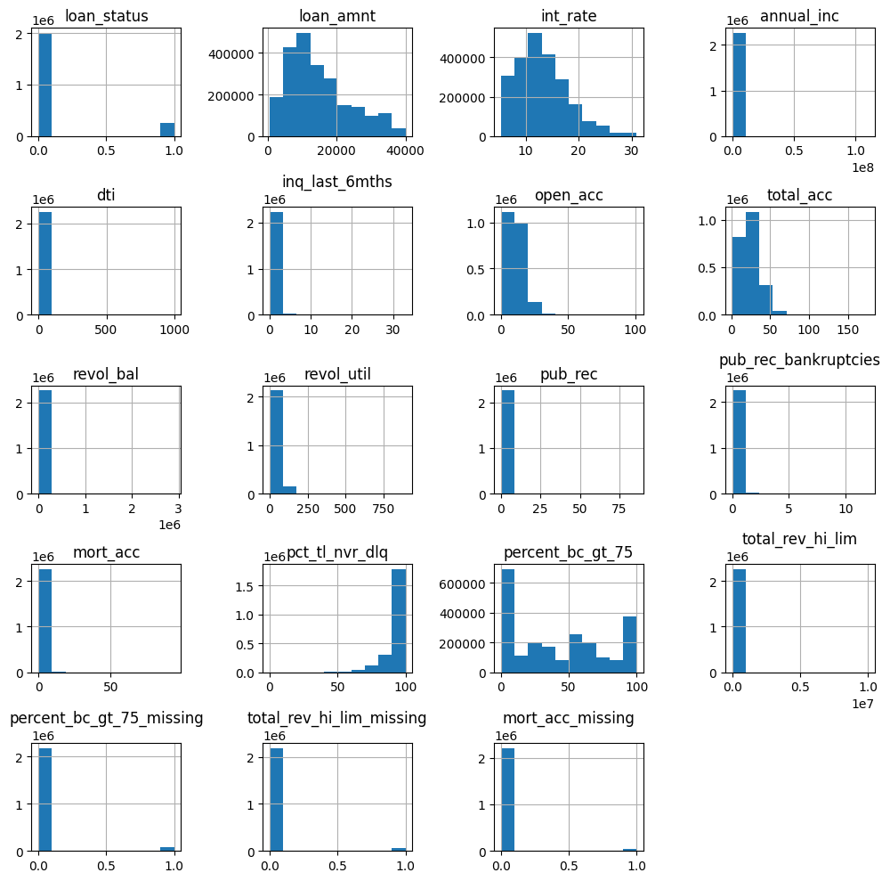

```python
loan_df_4.hist(figsize=(10, 10))
plt.tight_layout()
plt.show()
```

```python
loan_df_4.select_dtypes(include="number").skew().sort_values()
```

```
pct_tl_nvr_dlq               -2.279116
revol_util                    0.012565
percent_bc_gt_75              0.357905
int_rate                      0.768058
loan_amnt                     0.777780
total_acc                     1.007457
open_acc                      1.315544
mort_acc                      1.812723
inq_last_6mths                2.066187
loan_status                   2.396902
pub_rec_bankruptcies          3.372410
percent_bc_gt_75_missing      5.199649
total_rev_hi_lim_missing      5.404941
mort_acc_missing              6.498810
pub_rec                      11.376806
revol_bal                    13.232015
dti                          29.213095
total_rev_hi_lim             31.816698
annual_inc                  493.885991
dtype: float64
```

```python
skewed_cols = ["pub_rec", "revol_bal", "dti",
               "total_rev_hi_lim", "annual_inc"]
```

```python
from sklearn.preprocessing import PowerTransformer

pt = PowerTransformer(method="yeo-johnson", standardize=False)
loan_df_4[skewed_cols] = pt.fit_transform(loan_df_4[skewed_cols])
```

```python
loan_df_4.select_dtypes(include="number").skew().sort_values()
```

```
pct_tl_nvr_dlq             -2.279116
revol_util                  0.012565
total_rev_hi_lim            0.130521
revol_bal                   0.189812
dti                         0.236834
annual_inc                  0.312637
percent_bc_gt_75            0.357905
int_rate                    0.768058
loan_amnt                   0.777780
total_acc                   1.007457
open_acc                    1.315544
mort_acc                    1.812723
pub_rec                     1.872126
inq_last_6mths              2.066187
loan_status                 2.396902
pub_rec_bankruptcies        3.372410
percent_bc_gt_75_missing    5.199649
total_rev_hi_lim_missing    5.404941
mort_acc_missing            6.498810
dtype: float64
```

### One-hot Encoding

```python
one_hot_cols = loan_df_4.select_dtypes(include="object").columns
loan_df_4 = pd.get_dummies(data=loan_df_4, columns=one_hot_cols,
                           drop_first=True, dtype=int)
```

```python
loan_df_4.shape
```

```
(2260638, 129)
```

## Model Preparation

```python
loan_df_5 = loan_df_4.copy()
```

```python
y = loan_df_5["loan_status"]
X = loan_df_5.drop("loan_status", axis=1)
```

### Balancing Target Classes

```python
y.value_counts(normalize=True)
```

```
loan_status
0    0.883907
1    0.116093
Name: proportion, dtype: float64
```

### Train Test Split

```python
from sklearn.model_selection import train_test_split
X_train, X_test, y_train, y_test = train_test_split(X,
                                                    y,
                                                    test_size=0.2,
                                                    stratify=y,
                                                    random_state=11)
```

### Standardization

```python
cols_to_standardize = [loan_df_3.columns[~(
    loan_df_3.columns.isin(["loan_status",
                            "percent_bc_gt_75_missing",
                            "total_rev_hi_lim_missing",
                            "mort_acc_missing"]))]]
```

```python
cols_to_standardize
```

```
[Index(['loan_amnt', 'term', 'int_rate', 'sub_grade', 'annual_inc',
        'emp_length', 'home_ownership', 'verification_status', 'purpose', 'dti',
        'inq_last_6mths', 'open_acc', 'total_acc', 'revol_bal', 'revol_util',
        'pub_rec', 'pub_rec_bankruptcies', 'mort_acc', 'pct_tl_nvr_dlq',
        'percent_bc_gt_75', 'total_rev_hi_lim', 'addr_state',
        'application_type'],
       dtype='object')]
```

```python
from sklearn.preprocessing import StandardScaler

ss = StandardScaler()

X_train_scaled = ss.fit_transform(X_train)
X_train_scaled = pd.DataFrame(X_train_scaled, columns=X_train.columns, index=X_train.index)

X_test_scaled = ss.transform(X_test)
X_test_scaled = pd.DataFrame(X_test_scaled, columns=X_test.columns, index=X_test.index)
```